# STAT 360: Computational Statistics and Data Analysis

## PS 3.1 - Marcus Haldane

### Load Relevant R Libraries

```r
rm(list = ls())
library(rmarkdown); library(knitr); library(moments);
library(scatterplot3d); library(corrplot); library(pso)
library(psych); library(GPArotation); library(lavaan)
```

### 3.05 Climate Change, Theory of Planned Behavior, and Values

#### Part (a)

```r
# Written answer below
```

As can be seen in the path diagram, there are 9 dimensions, those being Attitude2, Attitude1, Individualist, Egalitarian, Fatalist, Norm1, Norm2, Intention1, and Intention2. The number of data points can thus be said to be equal to [9 * (9 + 1)]/2 = 45. Thus the number of unique data points provided by the dimensions in this diagram is 45.

#### Part (b)

```r
# Written answer below
```

There is an additional variance hidden for each independent variable on this path diagram. The independent variables are each of the error or disturbances, a1, a2, z_i, i5, n2, and n3, as well as the Individualist and Egalitarian dimensions, for a total of 8 independent variables. Since there are 8 independent variables, there are 8 additional variances hidden from this path diagram.

#### Part (c)

```r
# Written answer below
```

In order to properly establish the scale of each factor, one path corresponding to one of the dimensions that loads onto each of the factors must be fixed. For this path diagram, one path must be fixed for the Attitudes factor, the Intention factor, and the Norm factor, for a total of 3 fixed paths. Those 3 fixed paths could be any combination of the paths which symbolize a loading from the dimensions to their respective factors. For example, the paths between Attitudes and Attitude1, Intention and Intention1, Norm and Norm1 could all be fixed so that the scale of each of those factors could be properly established.

#### Part (d)

```r
# Written answer below
```

By my count, there are 24 paths shown on them Climate Change and Behavior path diagram, as well as an additional 8 hidden variances, which add up to 32 parameters for this path diagram. Furthermore, 3 parameters will be fixed, as explained in Part (c), meaning the actual number of parameters to be estimated will be 29. Therefore, the 45 data points identified in Part (a) indicate that this model is already over-identified, and that no additional paths need to be fixed in order to properly establish model identifiability.

### Exercise 3.06 - Cavity Trees, Den Order, and Fishers (continued)

#### Part (a)

```r
# Insert code or written answer here
CavityTreesCovarianceMatrix <- matrix(c(78.45,  -2.96,  -4.73,  -183.75,    -1.96,
                                        -2.96,  0.21,   0.62,   12.3,   0.07,
                                        -4.73,  0.62,   34.23,  -147.01,    2.07,
                                        -183.75,    12.3,   -147.01,    2942.23,    -12.38,
                                        -1.96,  0.07,   2.07,   -12.38, 0.21),
                                      byrow = T, nrow = 5, ncol = 5,
                                      dimnames = list(c("DBH", "Type", "Slope", "Aspect", "Order"),
                                                      c("DBH", "Type", "Slope", "Aspect", "Order")))
CavityTreesCovarianceMatrix
```

```
##            DBH  Type   Slope  Aspect  Order
## DBH      78.45 -2.96   -4.73 -183.75  -1.96
## Type     -2.96  0.21    0.62   12.30   0.07
## Slope    -4.73  0.62   34.23 -147.01   2.07
## Aspect -183.75 12.30 -147.01 2942.23 -12.38
## Order    -1.96  0.07    2.07  -12.38   0.21
```

#### Part (b)

```r
# Insert code or written answer here
CavityTreesDimNames_p <- list(dimnames(CavityTreesCovarianceMatrix)[[1]][1:4],dimnames(CavityTreesCovarianceMatrix)[[1]][1:4])
CavityTreesCovarianceMatrix_p <- CavityTreesCovarianceMatrix[1:4,1:4]
CavityTreesCorrelationMatrix_p <-  (solve(sqrt(diag(diag(CavityTreesCovarianceMatrix_p))))) %*% CavityTreesCovarianceMatrix_p %*% t(solve(sqrt(diag(diag(CavityTreesCovarianceMatrix_p)))))
dimnames(CavityTreesCorrelationMatrix_p) <- CavityTreesDimNames_p
# CavityTreesCorrelationMatrix_p
A <- pca(r = CavityTreesCorrelationMatrix_p, nfactors = 2, rotate = "varimax")$loadings[]
A
```

```
##               RC1         RC2
## DBH    -0.8882565  0.02139331
## Type    0.9461161  0.02793651
## Slope   0.2218672  0.92845813
## Aspect  0.5437402 -0.74969304
```

#### Part (c)

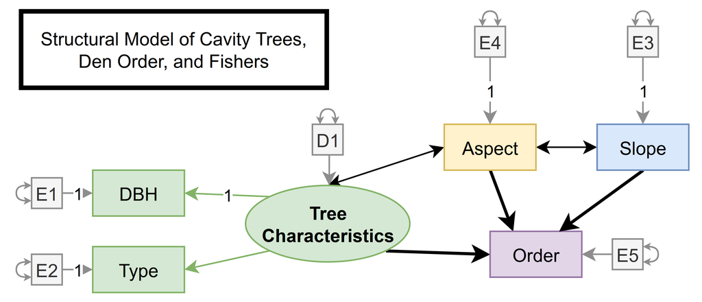

```r
# Image below
include_graphics("C:/Users/mrhal/Downloads/STAT360_PS3_2_E2_alt.png")
```

#### Part (d)

```r
# Insert code or written answer here
# Constructing the Matrix of Regression Coefficients among the DVs
#            FROM
#####DBH #Type #Slope #Aspect #Order #Tree Characteristics
BT <- matrix(c(0, 0, 0, 0, 0, 1, # DBH
               0, 0, 0, 0, 0, NA, # Type
               0, 0, 0, 0, 0, 0, # Slope             # TO
               0, 0, NA, NA, 0, NA, # Aspect
               0, 0, NA, NA, 0, NA, # Order
               0, 0, 0, NA, 0, 0), # Tree Characteristics
             byrow = T, nrow = 6, ncol = 6,
             dimnames = list(c("DBH", "Type", "Slope", "Aspect", "Order", "Tree Characteristics"),
                             c("DBH", "Type", "Slope", "Aspect", "Order", "Tree Characteristics")))
BT
```

```
##                      DBH Type Slope Aspect Order Tree Characteristics
## DBH                    0    0     0      0     0                    1
## Type                   0    0     0      0     0                   NA
## Slope                  0    0     0      0     0                    0
## Aspect                 0    0    NA     NA     0                   NA
## Order                  0    0    NA     NA     0                   NA
## Tree Characteristics   0    0     0     NA     0                    0
```

#### Part (e)

```r
# Insert code or written answer here
# Constructing the Matrix of Regression Coefficients between the IVs and the DVs
#            FROM
              #E1 E2 E3 E4 E5 D1
GM <- matrix(c(1, 0, 0, 0, 0, 0, # DBH
               0, 1, 0, 0, 0, 0, # Type
               0, 0, 1, 0, 0, 0, # Slope             # TO
               0, 0, 0, 1, 0, 0, # Aspect
               0, 0, 0, 0, NA, 0, # Order
               0, 0, 0, 0, 0, NA), # Tree Characteristics
             byrow = T, nrow = 6, ncol = 6,
             dimnames = list(c("DBH", "Type", "Slope", "Aspect", "Order", "Tree Characteristics"),
                             c("E1", "E2", "E3", "E4", "E5","D1")))
GM
```

```
##                      E1 E2 E3 E4 E5 D1
## DBH                   1  0  0  0  0  0
## Type                  0  1  0  0  0  0
## Slope                 0  0  1  0  0  0
## Aspect                0  0  0  1  0  0
## Order                 0  0  0  0 NA  0
## Tree Characteristics  0  0  0  0  0 NA
```

#### Part (f)

```r
# Insert code or written answer here
# Constructing the Matrix of Variances among the IVs
#            FROM
              #E1 E2 E3 E4 E5 D1
PH <- matrix(c(NA, 0, 0, 0, 0, 0, # E1
               0, NA, 0, 0, 0, 0, # E2
               0, 0, NA, 0, 0, 0, # E3             # TO
               0, 0, 0, NA, 0, 0, # E4
               0, 0, 0, 0, NA, 0, # E5
               0, 0, 0, 0, 0, NA), # D1
             byrow = T, nrow = 6, ncol = 6,
             dimnames = list(c("E1", "E2", "E3", "E4", "E5","D1"),
                             c("E1", "E2", "E3", "E4", "E5","D1")))
PH
```

```
##    E1 E2 E3 E4 E5 D1
## E1 NA  0  0  0  0  0
## E2  0 NA  0  0  0  0
## E3  0  0 NA  0  0  0
## E4  0  0  0 NA  0  0
## E5  0  0  0  0 NA  0
## D1  0  0  0  0  0 NA
```

### Exercise 3.07 - Plant Diversity and Environmental Factors (continued)

#### Part (a)

```r
# Written answer below
```

There are 12 dimensions and 4 factors contained in this path diagram.

#### Part (b)

```r
# Written answer below
```

One path between a dimension and its respective factor must be fixed, for each of the factors in the path diagram. This means that a total of four paths must be fixed to properly establish the scale of each factor. There are a large number of possible combinations of which four paths could be fixed to properly establish the scale of each factor, but a simple example is to fix the paths between soil carbon and Abiotic Stress, animal activity and Disturbance, standing biomass and Community Biomass, & Plant Diversity and species count.  
Additionally, the number of data points for this model would be [12 * (12 + 1)]/2 = 78, while the number of parameters to be estimated would be 46. [(12 displayed regression coefficients between dimensions and factors, 6 displayed regression coefficients between factors, 12 hidden regression coefficients between errors and dimensions, 4 hidden regression coefficients between disturbances and factors, and 16 variances on those hidden errors and disturbances) - the 4 fixed paths used to establish scale between factors and their respective dimensions] Since the number of parameters is less than the number of data points, no additional paths need to be fixed.

#### Part (c)

```r
# Written answer below
```

Each of the dimensions and factors on the path diagram are dependent variables, so each of those 16 has an error or disturbance. Therefore, there are 16 additional paths that represent regression coefficients hidden in this path diagram.

#### Part (d)

```r
# Written answer below
```

Each of the dimensions and factors on the path diagram are dependent variables, so each of those 16 has an error or disturbance. Those 16 errors and disturbances each have a variance, as they are the only independent variables for this path diagram. Thus, there are 16 variances hidden in this path diagram.

#### Part (e)

```r
# Written answer below
```

Since this path diagram has 12 dimensions, there are 12 covariances, one for each of the dimensions. Additionally, each of the dimensions has a variance with every other dimension, resulting in an additional 66 variances for a total of 78 unique data points.

#### Part (f)

```r
# Written answer below
```

[output not shown]

### Exercise 3.08 - Schizophrenia and Language Processing (continued)

#### Part (a)

```r
# Written answer below
```

The list of independent variables is: E1, E2, E3, E4, E5, E6, E7, D1, D2, D3  
The list of dependent variables is: Halluc., Thought disorgan., Unusual thought, Duration, Right ear, Left ear, Either ear, Positive Symptoms, Attention, Laterality  
All 10 of the independent variables are hidden, in the form of errors and disturbances (labeled E* and D*).  
All 10 of the dependent variables are not hidden, and are the original dimensions and the factors.

#### Part (b)

```r
# Written answer below
```

The row names would be the list of dependent variables from the path diagram: Halluc., Thought disorgan., Unusual thought, Duration, Right ear, Left ear, Either ear, Positive Symptoms, Attention, Laterality  
The column names would also be the list of dependent variables from the path diagram: Halluc., Thought disorgan., Unusual thought, Duration, Right ear, Left ear, Either ear, Positive Symptoms, Attention, Laterality

#### Part (c)

```r
# Written answer below
```

[output not shown]

#### Part (d)

```r
# Written answer below
```

The row names would be the list of independent variables from the path diagram: E1, E2, E3, E4, E5, E6, E7, D1, D2, D3  
The column names would also be the list of independent variables from the path diagram: E1, E2, E3, E4, E5, E6, E7, D1, D2, D3